# Keras mnist

```python
import numpy as np
import pandas as pd
from numpy import reshape
%matplotlib inline

import warnings
warnings.filterwarnings("ignore")
```

```python
data_train = pd.read_csv("train.csv")
data_test = pd.read_csv("test.csv")
```

```python
from matplotlib import pylab, gridspec
from matplotlib import pyplot as plt
```

# keras

```python
import keras
from keras.datasets import mnist
from keras.models import Sequential
from keras.layers import Dense, Dropout, Flatten
from keras.layers import Conv2D, MaxPooling2D
from keras import backend as K
from keras.callbacks import ReduceLROnPlateau
```

```python
X_train = data_train.drop(["label"], axis = 1)
y_train = pd.get_dummies(data_train["label"])
```

```python
X_train = X_train.values.reshape(X_train.shape[0], 28, 28, 1)
```

```python
model = Sequential()

model.add(Conv2D(32, kernel_size=(3, 3),
                 activation='relu',
                 input_shape=(28,28,1)))
model.add(Conv2D(32, kernel_size=(3, 3), activation='relu'))
model.add(MaxPooling2D(pool_size=(2, 2)))
model.add(Dropout(0.25))

model.add(Conv2D(64, (3, 3), activation='relu'))
model.add(Conv2D(64, (3, 3), activation='relu'))
model.add(MaxPooling2D(pool_size=(2, 2)))
model.add(Dropout(0.25))

model.add(Conv2D(128, (3, 3), activation='relu'))
model.add(MaxPooling2D(pool_size=(2, 2)))
model.add(Dropout(0.25))

model.add(Flatten())
model.add(Dense(128, activation='relu'))
model.add(Dropout(0.5))
model.add(Dense(10, activation='softmax')) #Класс. 10 различных объектов / классов - слой с 10 нейронами

model.compile(loss=keras.losses.categorical_crossentropy,
              optimizer=keras.optimizers.Adadelta(),
              metrics=['accuracy'])
```

softmax возвращает вероятность принадлежности картинки к каждому классу. Т.е. на выходе получается матрица с 10-ю столбцами (один столбец на каждый класс) с вероятностями.

Слой Dense - это простой полносвязный слой, когда каждый нейрон предыдущего слоя связан с каждым нейроном данного. Обычно во всех сверточных сетях в последних слоях используют 2-3 полносвязных слоя, которые следуют за слоями свертки, пулинга и "выпрямления" (слой: Flatten).

слой Flatten - "выпрямляет" 2+-мерные матрицы в одномерные вектора.

Dropout - один из методов регуляризации (используется для борьбы с переобучением).

relu - одна из самых популярных нелинейных функций активации нейронов:

f(x) = max(0, x)

MaxPooling2D(pool_size=(2, 2)) проплывает окошком размером (2, 2) по матрице и для каждого окошка выбирает максимальное значение, уменьшая размер исходной матрицы

```python
model.summary()
```

```
_________________________________________________________________
Layer (type)                 Output Shape              Param #
=================================================================
conv2d_1 (Conv2D)            (None, 26, 26, 32)        320
_________________________________________________________________
conv2d_2 (Conv2D)            (None, 24, 24, 32)        9248
_________________________________________________________________
max_pooling2d_1 (MaxPooling2 (None, 12, 12, 32)        0
_________________________________________________________________
dropout_1 (Dropout)          (None, 12, 12, 32)        0
_________________________________________________________________
conv2d_3 (Conv2D)            (None, 10, 10, 64)        18496
_________________________________________________________________
conv2d_4 (Conv2D)            (None, 8, 8, 64)          36928
_________________________________________________________________
max_pooling2d_2 (MaxPooling2 (None, 4, 4, 64)          0
_________________________________________________________________
dropout_2 (Dropout)          (None, 4, 4, 64)          0
_________________________________________________________________
conv2d_5 (Conv2D)            (None, 2, 2, 128)         73856
_________________________________________________________________
max_pooling2d_3 (MaxPooling2 (None, 1, 1, 128)         0
_________________________________________________________________
dropout_3 (Dropout)          (None, 1, 1, 128)         0
_________________________________________________________________
flatten_1 (Flatten)          (None, 128)               0
_________________________________________________________________
dense_1 (Dense)              (None, 128)               16512
_________________________________________________________________
dropout_4 (Dropout)          (None, 128)               0
_________________________________________________________________
dense_2 (Dense)              (None, 10)                1290
=================================================================
Total params: 156,650
Trainable params: 156,650
Non-trainable params: 0
_________________________________________________________________
```

# Model.fit

```python
lr_reduce = ReduceLROnPlateau(monitor='val_acc', factor=0.1, epsilon=0.0001, patience=1, verbose=1)
model.fit(X_train, y_train, batch_size=128, epochs=20, verbose=1, validation_split=0.35, callbacks=[lr_reduce])
```

```
Train on 27300 samples, validate on 14700 samples

Epoch 00004: ReduceLROnPlateau reducing learning rate to 0.1.

Epoch 00009: ReduceLROnPlateau reducing learning rate to 0.010000000149011612.

Epoch 00010: ReduceLROnPlateau reducing learning rate to 0.0009999999776482583.

Epoch 00011: ReduceLROnPlateau reducing learning rate to 9.999999310821295e-05.

Epoch 00012: ReduceLROnPlateau reducing learning rate to 9.999999019782991e-06.

Epoch 00013: ReduceLROnPlateau reducing learning rate to 9.99999883788405e-07.

Epoch 00014: ReduceLROnPlateau reducing learning rate to 9.99999883788405e-08.

Epoch 00015: ReduceLROnPlateau reducing learning rate to 9.999998695775504e-09.

Epoch 00016: ReduceLROnPlateau reducing learning rate to 9.99999905104687e-10.

Epoch 00017: ReduceLROnPlateau reducing learning rate to 9.999998606957661e-11.

Epoch 00018: ReduceLROnPlateau reducing learning rate to 9.99999874573554e-12.

Epoch 00019: ReduceLROnPlateau reducing learning rate to 9.999999092680235e-13.

Epoch 00020: ReduceLROnPlateau reducing learning rate to 9.9999988758398e-14.
```

```
<keras.callbacks.History at 0x7f4e61369400>
```

```python
from random import random
```

```python
X_test = data_test.values.reshape(data_test.shape[0], 28, 28, 1)
```

# Wrong pred

```python
pred2 = model.predict(X_train).argmax(1)
data_wrong_pred = data_train[data_train["label"] != pred2]
```

```python
truepredpercent = 100 - len(data_wrong_pred) / len(data_test) * 100
print('True predict percent: ' + str(truepredpercent) + ' %')
```

```
True predict percent: 98.9 %
```

# Custom mnist dataset

# Шумы

(x_train, y_train), (x_test, y_test) = mnist.load_data()

```python
from keras.layers import Input, Dense, Flatten, Reshape
from keras.models import Model

def create_dense_ae():
    # Размерность кодированного представления
    encoding_dim = 49

    # Энкодер
    # Входной плейсхолдер
    input_img = Input(shape=(28, 28, 1)) # 28, 28, 1 - размерности строк, столбцов, фильтров одной картинки, без батч-размерности
    # Вспомогательный слой решейпинга
    flat_img = Flatten()(input_img)
    # Кодированное полносвязным слоем представление
    encoded = Dense(encoding_dim, activation='relu')(flat_img)

    # Декодер
    # Раскодированное другим полносвязным слоем изображение
    input_encoded = Input(shape=(encoding_dim,))
    flat_decoded = Dense(28*28, activation='sigmoid')(input_encoded)
    decoded = Reshape((28, 28, 1))(flat_decoded)

    # Модели, в конструктор первым аргументом передаются входные слои, а вторым выходные слои
    # Другие модели можно так же использовать как и слои
    encoder = Model(input_img, encoded, name="encoder")
    decoder = Model(input_encoded, decoded, name="decoder")
    autoencoder = Model(input_img, decoder(encoder(input_img)), name="autoencoder")
    return encoder, decoder, autoencoder
```

```python
encoder, decoder, autoencoder = create_dense_ae()
autoencoder.compile(optimizer='adam', loss='binary_crossentropy')
```

```python
autoencoder.fit(X_train, X_train,
                epochs=50,
                batch_size=256,
                shuffle=True,
                validation_data=(X_test,X_test))
```

```
Train on 42000 samples, validate on 28000 samples
```

```
<keras.callbacks.History at 0x7f5e3072d320>
```

```python
%matplotlib inline
import seaborn as sns
import matplotlib.pyplot as plt

def plot_digits(*args):
    args = [x.squeeze() for x in args]
    n = min([x.shape[0] for x in args])

    plt.figure(figsize=(2*n, 2*len(args)))
    for j in range(n):
        for i in range(len(args)):
            ax = plt.subplot(len(args), n, i*n + j + 1)
            plt.imshow(args[i][j])
            plt.gray()
            ax.get_xaxis().set_visible(False)
            ax.get_yaxis().set_visible(False)

    plt.show()
```

```python
n = 10

imgs = X_test[:n]
encoded_imgs = encoder.predict(imgs, batch_size=n)
encoded_imgs[0]
```

```
array([ 245.29765 ,  701.6057  ,  761.3304  ,  165.328   ,  499.6398  ,
       1094.9662  ,  549.5508  ,    0.      ,  382.70953 ,  457.17188 ,
         48.087883,  485.5578  ,   93.557785,   87.27439 ,    0.      ,
       1034.1147  ,   69.0833  ,  847.27435 ,  338.7796  ,  793.1704  ,
        191.88924 ,  698.6954  ,  144.16766 ,    0.      ,  108.6353  ,
          0.      ,  233.87553 ,  234.79764 ,    0.      ,  164.46379 ,
        518.856   ,  922.26624 ,    0.      ,  626.55145 ,  649.39197 ,
        899.83606 ,  975.3344  ,  837.226   ,    0.      ,  899.9586  ,
          0.      ,  352.00766 ,    0.      ,  745.9848  ,    0.      ,
        976.2084  ,  796.4847  ,  553.48016 ,    0.      ], dtype=float32)
```

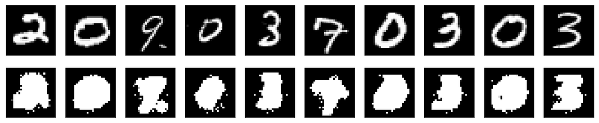

```python
decoded_imgs = decoder.predict(encoded_imgs, batch_size=n)

plot_digits(imgs, decoded_imgs)
```

```python
import keras.backend as K
from keras.layers import Lambda

batch_size = 16

def create_denoising_model(autoencoder):
    def add_noise(x):
        noise_factor = 0.5
        x = x + K.random_normal(x.get_shape(), 0.5, noise_factor)
        x = K.clip(x, 0., 1.)
        return x

    input_img  = Input(batch_shape=(batch_size, 28, 28, 1))
    noised_img = Lambda(add_noise)(input_img)

    noiser = Model(input_img, noised_img, name="noiser")
    denoiser_model = Model(input_img, autoencoder(noiser(input_img)), name="denoiser")
    return noiser, denoiser_model


noiser, denoiser_model = create_denoising_model(autoencoder)
denoiser_model.compile(optimizer='adam', loss='binary_crossentropy')
```

```python
denoiser_model.fit(X_train, X_train,
                   epochs=200,
                   batch_size=batch_size,
                   shuffle=True,
                   validation_data=(X_test, X_test))
```

[output not shown]

```python
n = 10

imgs = x_test[:batch_size]
noised_imgs = noiser.predict(imgs, batch_size=batch_size)
encoded_imgs = encoder.predict(noised_imgs[:n],  batch_size=n)
decoded_imgs = decoder.predict(encoded_imgs[:n], batch_size=n)

plot_digits(imgs[:n], noised_imgs, decoded_imgs)
```

[output not shown]